# DS 340W Honors Option

Malcolm Zerbe

# Front Matter

```r
# Load libraries
suppressMessages({
  library(tidyverse)
  library(ggrepel)
  library(ggcorrplot)
  library(tidymodels)
  library(xgboost)
  library(vip)
})
```

```r
# Load data
fg_2015_2023 <- read.csv("fangraphs-leaderboards.csv")
ev_2023 <- read.csv("exit_velocity_2023.csv")
ev_2022 <- read.csv("exit_velocity_2022.csv")
ev_2021 <- read.csv("exit_velocity_2021.csv")
ev_2020 <- read.csv("exit_velocity_2020.csv")
ev_2019 <- read.csv("exit_velocity_2019.csv")
ev_2018 <- read.csv("exit_velocity_2018.csv")
ev_2017 <- read.csv("exit_velocity_2017.csv")
ev_2016 <- read.csv("exit_velocity_2016.csv")
ev_2015 <- read.csv("exit_velocity_2015.csv")
xstats_2023 <- read.csv("expected_stats_2023.csv")
xstats_2022 <- read.csv("expected_stats_2022.csv")
xstats_2021 <- read.csv("expected_stats_2021.csv")
xstats_2020 <- read.csv("expected_stats_2020.csv")
xstats_2019 <- read.csv("expected_stats_2019.csv")
xstats_2018 <- read.csv("expected_stats_2018.csv")
xstats_2017 <- read.csv("expected_stats_2017.csv")
xstats_2016 <- read.csv("expected_stats_2016.csv")
xstats_2015 <- read.csv("expected_stats_2015.csv")
```

# Introduction

Our goal is to predict the future performance of Major League Baseball (MLB) players. MLB players can contribute to their teams in a variety of distinct ways, including batting, fielding, running, and pitching. This analysis will focus on batting alone. Baseball organizations and fans use a variety of hitting statistics to quantify offensive performance. These range from the primitive batting average (BA) and slugging percentage (SLG) to the more advanced weighted on-base average (wOBA) and weighted runs created plus (wRC+). This project will use wRC+ to define the success of a batter.

wRC+ is an all-encompassing hitting metric that remedies the flaws of competing hitting statistics by (a) weighting each hit type according to its average value, (b) accounting for the value of walks, and (c) adjusting for the run environment of various ballparks. Additionally, wRC+ is easy to interpret with 100 being average and every integer above or below 100 representing a percentage better or worse than average, respectfully (i.e., 120 is 20% better than average, 85 is 15% worse than average). Lastly, this metric is directly comparable across different seasons unlike most other hitting metrics due to their varying league averages each season.

We want to build a machine learning (ML) model to predict the wRC+ of MLB hitters in future seasons. To build a supervised ML model, we need a set of labeled data records structured in feature-output pairs so that we can attempt to learn the function between them. We will be trying to use past performance to predict future wRC+.

*Future wRC+ ~ Past Performance*

This seems like a plausible idea. For example, we may expect reigning MVP Shohei Ohtani to have a much higher wRC+ in 2024 than most other hitters when looking at past performance. It would not make very much sense to simply predict the league average wRC+ for every player in the league because many players have demonstrated sustainable offensive skills that are more likely to repeat than not. While this method will never be perfect (projecting player performance is difficult, and will never be flawless), the results should provide enough signal to serve as a useful projection.

# Data Sources

First, we must collect to train models. All data comes from FanGraphs and Baseball Savant, two of the most popular sources of baseball data.

```r
# View FanGraphs data
glimpse(fg_2015_2023)
```

```
Rows: 5,732
Columns: 35
$ Season         <int> 2015, 2015, 2015, 2015, 2015, 2015, 2015, 2015, 2015, 2015, 2015, 2015, 2015, 2015, 2015, 2015, 2015…
$ Name           <chr> "Kyle Blanks", "Will Venable", "Victor Martinez", "Juan Uribe", "Carlos Beltrán", "Brandon Barnes", …
$ Team           <chr> "TEX", "- - -", "DET", "- - -", "NYY", "COL", "TEX", "TBR", "MIN", "BOS", "ATL", "CIN", "CIN", "CIN"…
$ Age            <int> 28, 32, 36, 36, 38, 29, 36, 29, 39, 39, 38, 29, 34, 30, 37, 36, 37, 30, 37, 41, 29, 35, 30, 33, 39, …
$ PA             <int> 71, 390, 485, 397, 531, 281, 619, 73, 567, 614, 436, 678, 623, 94, 544, 563, 516, 32, 72, 438, 203, …
$ AVG            <dbl> 0.31343284, 0.24355301, 0.24545454, 0.25277778, 0.27615063, 0.25098039, 0.28747795, 0.30985915, 0.23…
$ AVG_Plus       <dbl> 122.45575, 93.78614, 95.89717, 97.10495, 107.88988, 96.41449, 112.31538, 121.05954, 93.73612, 106.55…
$ OBP            <dbl> 0.3521127, 0.3195876, 0.3010309, 0.3198992, 0.3370998, 0.3142857, 0.3344103, 0.3150685, 0.2927690, 0…
$ OBP_Plus       <dbl> 110.59753, 98.97364, 94.55291, 98.69626, 105.88204, 96.96436, 105.03728, 98.96207, 91.95785, 113.054…
$ SLG            <dbl> 0.5223881, 0.3495702, 0.3659091, 0.4166667, 0.4707113, 0.3411765, 0.4532628, 0.6056338, 0.4088292, 0…
$ SLG_Plus       <dbl> 126.41918, 85.21111, 88.55089, 101.66916, 113.91327, 83.24910, 109.69069, 146.56485, 98.93765, 133.8…
$ OPS            <dbl> 0.8745007, 0.6691578, 0.6669400, 0.7365659, 0.8078111, 0.6554622, 0.7876731, 0.9207023, 0.7015981, 0…
$ BB_Rate        <dbl> 0.05633803, 0.09487179, 0.06391753, 0.08564232, 0.08474576, 0.07473310, 0.06623586, 0.01369863, 0.06…
```

[output cut: 22 more lines]

FanGraphs provides many essential metrics, including our target variable wRC+. Each observation represents a specific player in a specific season dating back to 2015. The data frame contains standard, more commonly used offensive metrics like batting average and slugging percentage, player tendencies like swing percentage and contact percentage, batted ball metrics like hard hit percentage, and more. We suspect that many of these metrics will play a crucial role in predicting future wRC+.

```r
# View batted ball information from Baseball Savant
glimpse(ev_2023)
```

```
Rows: 651
Columns: 18
$ last_name..first_name <chr> "Kwan, Steven", "Semien, Marcus", "Acuña Jr., Ronald", "Ramírez, José", "Arraez, Luis", "Hoer…
$ player_id             <int> 680757, 543760, 660670, 608070, 650333, 663538, 608324, 677951, 643446, 518692, 665489, 65040…
$ attempts              <int> 570, 565, 562, 544, 544, 542, 537, 529, 526, 521, 506, 504, 497, 494, 492, 492, 492, 491, 490…
$ avg_hit_angle         <dbl> 10.7, 19.1, 7.4, 18.0, 11.5, 10.5, 17.6, 15.7, 14.4, 15.2, 10.5, 15.1, 16.6, 10.1, 12.6, 14.8…
$ anglesweetspotpercent <dbl> 37.4, 37.5, 33.6, 36.8, 44.7, 33.2, 35.8, 34.4, 31.9, 46.6, 32.4, 37.1, 37.4, 36.4, 37.0, 35.…
$ max_hit_speed         <dbl> 105.2, 108.6, 121.2, 111.6, 104.0, 109.2, 107.5, 113.8, 109.0, 110.6, 116.7, 112.4, 110.7, 10…
$ avg_hit_speed         <dbl> 86.0, 88.4, 94.7, 90.0, 88.3, 86.6, 88.6, 90.7, 86.0, 90.0, 92.1, 89.7, 88.7, 88.1, 88.4, 90.…
$ ev50                  <dbl> 94.1, 98.1, 106.4, 100.1, 95.7, 97.3, 98.1, 102.1, 96.0, 100.6, 104.1, 99.6, 98.7, 97.4, 99.6…
$ fbld                  <dbl> 87.6, 91.2, 98.4, 92.2, 90.4, 89.2, 91.9, 94.4, 89.7, 93.5, 95.3, 93.4, 92.8, 91.3, 92.7, 93.…
$ gb                    <dbl> 85.2, 85.2, 91.6, 90.6, 85.8, 86.5, 87.1, 88.3, 84.7, 85.1, 91.3, 85.6, 84.3, 86.3, 84.2, 86.…
$ max_distance          <int> 407, 433, 470, 431, 410, 404, 416, 442, 400, 442, 450, 454, 425, 424, 461, 447, 455, 440, 424…
$ avg_distance          <int> 149, 194, 162, 179, 168, 147, 183, 180, 154, 190, 160, 178, 187, 156, 168, 189, 148, 160, 177…
$ avg_hr_distance       <int> 386, 393, 420, 402, 379, 380, 381, 411, 376, 400, 403, 394, 388, 386, 400, 397, 396, 392, 397…
$ ev95plus              <int> 107, 209, 310, 220, 140, 181, 205, 241, 144, 220, 249, 203, 194, 174, 190, 226, 170, 196, 207…
$ ev95percent           <dbl> 18.8, 37.0, 55.2, 40.4, 25.7, 33.4, 38.2, 45.6, 27.4, 42.2, 49.2, 40.3, 39.0, 35.2, 38.6, 45.…
$ barrels               <int> 6, 37, 86, 38, 19, 10, 29, 61, 7, 58, 56, 40, 41, 23, 37, 52, 30, 38, 41, 26, 60, 57, 14, 66,…
$ brl_percent           <dbl> 1.1, 6.5, 15.3, 7.0, 3.5, 1.8, 5.4, 11.5, 1.3, 11.1, 11.1, 7.9, 8.2, 4.7, 7.5, 10.6, 6.1, 7.7…
$ brl_pa                <dbl> 0.8, 4.9, 11.7, 5.5, 3.1, 1.5, 4.0, 8.8, 1.1, 7.9, 8.2, 6.0, 6.2, 3.6, 5.4, 7.7, 4.5, 5.6, 5.…
```

```r
# View expected statistics from Baseball Savant
glimpse(xstats_2023)
```

```
Rows: 656
Columns: 14
$ last_name..first_name    <chr> "Semien, Marcus", "Acuña Jr., Ronald", "Freeman, Freddie", "Bregman, Alex", "Lowe, Nathani…
$ player_id                <int> 543760, 660670, 518692, 608324, 663993, 621566, 656941, 680757, 663586, 677594, 665742, 55…
$ year                     <int> 2023, 2023, 2023, 2023, 2023, 2023, 2023, 2023, 2023, 2023, 2023, 2023, 2023, 2023, 2023, …
$ pa                       <int> 753, 735, 730, 724, 724, 720, 720, 718, 715, 714, 708, 694, 694, 693, 691, 691, 691, 688, …
$ bip                      <int> 565, 562, 521, 537, 461, 445, 373, 570, 475, 481, 445, 395, 529, 482, 433, 490, 544, 542, …
$ ba                       <dbl> 0.276, 0.337, 0.331, 0.262, 0.262, 0.283, 0.197, 0.268, 0.281, 0.275, 0.275, 0.232, 0.276,…
$ est_ba                   <dbl> 0.262, 0.357, 0.323, 0.266, 0.263, 0.264, 0.220, 0.282, 0.273, 0.274, 0.284, 0.223, 0.294,…
$ est_ba_minus_ba_diff     <dbl> 0.014, -0.020, 0.008, -0.004, -0.001, 0.019, -0.023, -0.014, 0.008, 0.001, -0.009, 0.009, …
$ slg                      <dbl> 0.478, 0.596, 0.567, 0.441, 0.414, 0.604, 0.474, 0.370, 0.516, 0.485, 0.519, 0.391, 0.495,…
$ est_slg                  <dbl> 0.427, 0.660, 0.565, 0.430, 0.406, 0.558, 0.485, 0.358, 0.516, 0.475, 0.538, 0.419, 0.533,…
$ est_slg_minus_slg_diff   <dbl> 0.051, -0.064, 0.002, 0.011, 0.008, 0.046, -0.011, 0.012, 0.000, 0.010, -0.019, -0.028, -0…
$ woba                     <dbl> 0.354, 0.428, 0.411, 0.351, 0.340, 0.413, 0.350, 0.313, 0.363, 0.347, 0.395, 0.313, 0.343,…
$ est_woba                 <dbl> 0.333, 0.460, 0.408, 0.351, 0.339, 0.392, 0.364, 0.317, 0.365, 0.345, 0.408, 0.324, 0.369,…
$ est_woba_minus_woba_diff <dbl> 0.021, -0.032, 0.003, 0.000, 0.001, 0.021, -0.014, -0.004, -0.002, 0.002, -0.013, -0.011, …
```

This data is structured in a similar way as the FanGraphs data, with each observation representing a player in a season. This data could not be downloaded across multiple seasons, so a separate file exists for every season. Baseball Savant contains metrics that can only be calculated with MLB’s HawkEye technology. Some of the most notable offensive metrics contained in this data source are expected batting average (xBA), expected slugging percentage (xSLG), and expected weighted on-base average (xwOBA). These statistics were designed to isolate the skill of batters independent of luck, considering only exit velocity and launch angle and not the end result of balls-in-play.

# Data Wrangling

The data on FanGraphs and Baseball Savant share a common column. Let’s merge these two data sources so that we can utilize both suites of metrics.

```r
# Combine Baseball Savant data
bs_2023 <- left_join(x = ev_2023, y = xstats_2023, by = c("player_id", "last_name..first_name"))
bs_2022 <- left_join(x = ev_2022, y = xstats_2022, by = c("player_id", "last_name..first_name"))
bs_2021 <- left_join(x = ev_2021, y = xstats_2021, by = c("player_id", "last_name..first_name"))
bs_2020 <- left_join(x = ev_2020, y = xstats_2020, by = c("player_id", "last_name..first_name"))
bs_2019 <- left_join(x = ev_2019, y = xstats_2019, by = c("player_id", "last_name..first_name"))
bs_2018 <- left_join(x = ev_2018, y = xstats_2018, by = c("player_id", "last_name..first_name"))
bs_2017 <- left_join(x = ev_2017, y = xstats_2017, by = c("player_id", "last_name..first_name"))
bs_2016 <- left_join(x = ev_2016, y = xstats_2016, by = c("player_id", "last_name..first_name"))
bs_2015 <- left_join(x = ev_2015, y = xstats_2015, by = c("player_id", "last_name..first_name"))

# Split FanGraphs data up by season
fg_2023 <- fg_2015_2023 %>% filter(Season == 2023)
fg_2022 <- fg_2015_2023 %>% filter(Season == 2022)
fg_2021 <- fg_2015_2023 %>% filter(Season == 2021)
fg_2020 <- fg_2015_2023 %>% filter(Season == 2020)
fg_2019 <- fg_2015_2023 %>% filter(Season == 2019)
fg_2018 <- fg_2015_2023 %>% filter(Season == 2018)
fg_2017 <- fg_2015_2023 %>% filter(Season == 2017)
fg_2016 <- fg_2015_2023 %>% filter(Season == 2016)
fg_2015 <- fg_2015_2023 %>% filter(Season == 2015)

# Merge sources
vars_to_remove <- c("Team", "AVG", "OBP", "SLG", "OPS", "BB_Rate", "K_Rate", "Pull_Rate", "Cent_Rate", "Oppo_Rate", "GB_Rate", "NameASCII", "last_name..first_name", "attempts", "year", "pa", "bip", "ba", "slg", "woba", "ev95plus", "barrels", "est_ba_minus_ba", "est_slg_minus_slg", "est_woba_minus_woba", "est_ba_minus_ba_diff", "est_slg_minus_slg_diff", "est_woba_minus_woba_diff")

batting_2023 <- left_join(fg_2023, bs_2023, by = c("MLBAMID" = "player_id")) %>% select(PlayerId, MLBAMID, Name, everything(), -any_of(vars_to_remove))
batting_2022 <- left_join(fg_2022, bs_2022, by = c("MLBAMID" = "player_id")) %>% select(PlayerId, MLBAMID, Name, everything(), -any_of(vars_to_remove))
batting_2021 <- left_join(fg_2021, bs_2021, by = c("MLBAMID" = "player_id")) %>% select(PlayerId, MLBAMID, Name, everything(), -any_of(vars_to_remove))
batting_2020 <- left_join(fg_2020, bs_2020, by = c("MLBAMID" = "player_id")) %>% select(PlayerId, MLBAMID, Name, everything(), -any_of(vars_to_remove))
batting_2019 <- left_join(fg_2019, bs_2019, by = c("MLBAMID" = "player_id")) %>% select(PlayerId, MLBAMID, Name, everything(), -any_of(vars_to_remove))
batting_2018 <- left_join(fg_2018, bs_2018, by = c("MLBAMID" = "player_id")) %>% select(PlayerId, MLBAMID, Name, everything(), -any_of(vars_to_remove))
batting_2017 <- left_join(fg_2017, bs_2017, by = c("MLBAMID" = "player_id")) %>% select(PlayerId, MLBAMID, Name, everything(), -any_of(vars_to_remove))
batting_2016 <- left_join(fg_2016, bs_2016, by = c("MLBAMID" = "player_id")) %>% select(PlayerId, MLBAMID, Name, everything(), -any_of(vars_to_remove))
batting_2015 <- left_join(fg_2015, bs_2015, by = c("MLBAMID" = "player_id")) %>% select(PlayerId, MLBAMID, Name, everything(), -any_of(vars_to_remove))
```

```r
league_avgs <- data.frame(
  year = 2023:2015,
  lg_est_ba = c(0.248, 0.240, 0.242, 0.245, 0.247, 0.242, 0.249, 0.248, 0.245),
  lg_est_slg = c(0.413, 0.388, 0.407, 0.415, 0.424, 0.399, 0.415, 0.406, 0.390),
  lg_est_woba = c(0.320, 0.309, 0.317, 0.323, 0.319, 0.313, 0.318, 0.315, 0.310),
  lg_wOBA = c(0.318, 0.310, 0.319, 0.320, 0.325, 0.320, 0.326, 0.323, 0.318)
)

print(league_avgs)
```

| year | lg_est_ba | lg_est_slg | lg_est_woba | lg_wOBA |
| --- | --- | --- | --- | --- |
| 2023 | 0.248 | 0.413 | 0.320 | 0.318 |
| 2022 | 0.240 | 0.388 | 0.309 | 0.310 |
| 2021 | 0.242 | 0.407 | 0.317 | 0.319 |
| 2020 | 0.245 | 0.415 | 0.323 | 0.320 |
| 2019 | 0.247 | 0.424 | 0.319 | 0.325 |
| 2018 | 0.242 | 0.399 | 0.313 | 0.320 |
| 2017 | 0.249 | 0.415 | 0.318 | 0.326 |
| 2016 | 0.248 | 0.406 | 0.315 | 0.323 |
| 2015 | 0.245 | 0.390 | 0.310 | 0.318 |

```r
batting_2023 <- left_join(batting_2023, league_avgs, by = c("Season" = "year"))
batting_2022 <- left_join(batting_2022, league_avgs, by = c("Season" = "year"))
batting_2021 <- left_join(batting_2021, league_avgs, by = c("Season" = "year"))
batting_2020 <- left_join(batting_2020, league_avgs, by = c("Season" = "year"))
batting_2019 <- left_join(batting_2019, league_avgs, by = c("Season" = "year"))
batting_2018 <- left_join(batting_2018, league_avgs, by = c("Season" = "year"))
batting_2017 <- left_join(batting_2017, league_avgs, by = c("Season" = "year"))
batting_2016 <- left_join(batting_2016, league_avgs, by = c("Season" = "year"))
batting_2015 <- left_join(batting_2015, league_avgs, by = c("Season" = "year"))
```

```r
# Convert wOBA, xBA, xSLG, and xwOBA to Plus scale and calculate Z-O Swing%
batting_2023 <- batting_2023 %>% mutate(est_ba_plus = 100 * (est_ba / lg_est_ba), est_slg_plus = 100 * (est_slg / lg_est_slg), est_woba_plus = 100 * (est_woba / lg_est_woba), wOBA_Plus = 100 * (wOBA / lg_wOBA), Z_O_Swing_Rate = Z_Swing_Rate - O_Swing_Rate) %>% select(-est_ba, -lg_est_ba, -est_slg, -lg_est_slg, -est_woba, -lg_est_woba,-wOBA, -lg_wOBA)

batting_2022 <- batting_2022 %>% mutate(est_ba_plus = 100 * (est_ba / lg_est_ba), est_slg_plus = 100 * (est_slg / lg_est_slg), est_woba_plus = 100 * (est_woba / lg_est_woba), wOBA_Plus = 100 * (wOBA / lg_wOBA), Z_O_Swing_Rate = Z_Swing_Rate - O_Swing_Rate) %>% select(-est_ba, -lg_est_ba, -est_slg, -lg_est_slg, -est_woba, -lg_est_woba,-wOBA, -lg_wOBA)

batting_2021 <- batting_2021 %>% mutate(est_ba_plus = 100 * (est_ba / lg_est_ba), est_slg_plus = 100 * (est_slg / lg_est_slg), est_woba_plus = 100 * (est_woba / lg_est_woba), wOBA_Plus = 100 * (wOBA / lg_wOBA), Z_O_Swing_Rate = Z_Swing_Rate - O_Swing_Rate) %>% select(-est_ba, -lg_est_ba, -est_slg, -lg_est_slg, -est_woba, -lg_est_woba,-wOBA, -lg_wOBA)

batting_2020 <- batting_2020 %>% mutate(est_ba_plus = 100 * (est_ba / lg_est_ba), est_slg_plus = 100 * (est_slg / lg_est_slg), est_woba_plus = 100 * (est_woba / lg_est_woba), wOBA_Plus = 100 * (wOBA / lg_wOBA), Z_O_Swing_Rate = Z_Swing_Rate - O_Swing_Rate) %>% select(-est_ba, -lg_est_ba, -est_slg, -lg_est_slg, -est_woba, -lg_est_woba,-wOBA, -lg_wOBA)

batting_2019 <- batting_2019 %>% mutate(est_ba_plus = 100 * (est_ba / lg_est_ba), est_slg_plus = 100 * (est_slg / lg_est_slg), est_woba_plus = 100 * (est_woba / lg_est_woba), wOBA_Plus = 100 * (wOBA / lg_wOBA), Z_O_Swing_Rate = Z_Swing_Rate - O_Swing_Rate) %>% select(-est_ba, -lg_est_ba, -est_slg, -lg_est_slg, -est_woba, -lg_est_woba,-wOBA, -lg_wOBA)

batting_2018 <- batting_2018 %>% mutate(est_ba_plus = 100 * (est_ba / lg_est_ba), est_slg_plus = 100 * (est_slg / lg_est_slg), est_woba_plus = 100 * (est_woba / lg_est_woba), wOBA_Plus = 100 * (wOBA / lg_wOBA), Z_O_Swing_Rate = Z_Swing_Rate - O_Swing_Rate) %>% select(-est_ba, -lg_est_ba, -est_slg, -lg_est_slg, -est_woba, -lg_est_woba,-wOBA, -lg_wOBA)

batting_2017 <- batting_2017 %>% mutate(est_ba_plus = 100 * (est_ba / lg_est_ba), est_slg_plus = 100 * (est_slg / lg_est_slg), est_woba_plus = 100 * (est_woba / lg_est_woba), wOBA_Plus = 100 * (wOBA / lg_wOBA), Z_O_Swing_Rate = Z_Swing_Rate - O_Swing_Rate) %>% select(-est_ba, -lg_est_ba, -est_slg, -lg_est_slg, -est_woba, -lg_est_woba,-wOBA, -lg_wOBA)

batting_2016 <- batting_2016 %>% mutate(est_ba_plus = 100 * (est_ba / lg_est_ba), est_slg_plus = 100 * (est_slg / lg_est_slg), est_woba_plus = 100 * (est_woba / lg_est_woba), wOBA_Plus = 100 * (wOBA / lg_wOBA), Z_O_Swing_Rate = Z_Swing_Rate - O_Swing_Rate) %>% select(-est_ba, -lg_est_ba, -est_slg, -lg_est_slg, -est_woba, -lg_est_woba,-wOBA, -lg_wOBA)

batting_2015 <- batting_2015 %>% mutate(est_ba_plus = 100 * (est_ba / lg_est_ba), est_slg_plus = 100 * (est_slg / lg_est_slg), est_woba_plus = 100 * (est_woba / lg_est_woba), wOBA_Plus = 100 * (wOBA / lg_wOBA), Z_O_Swing_Rate = Z_Swing_Rate - O_Swing_Rate) %>% select(-est_ba, -lg_est_ba, -est_slg, -lg_est_slg, -est_woba, -lg_est_woba,-wOBA, -lg_wOBA)
```

We need to structure the data so that the features consist of past year metrics and the output label, future wRC+, is derived from the following season. It is important to not include, for any given row, information about the batter that came after or during the season of interest as this could cause severe data leakage. The use case of this model is predicting offensive results before the season even starts, so the model must be trained accordingly. We will also keep track of future plate appearances (PA) as this may be important for error metric calculations later.

With the data frames separated by individual seasons, we will merge previous seasons of metrics on to the following year’s wRC+. We will include 2 years worth of previous information.

```r
# Restructure data
predict_2023 <- batting_2023 %>% rename(Season_future = Season, wRC_Plus_future = wRC_Plus, PA_future = PA) %>% select(PlayerId, MLBAMID, Name, Season_future, wRC_Plus_future, PA_future) %>%
  left_join(batting_2022 %>% rename_with(~paste0(., "_past1"), -(1:3)), by = c("PlayerId", "MLBAMID", "Name")) %>%
  left_join(batting_2021 %>% rename_with(~paste0(., "_past2"), -(1:3)), by = c("PlayerId", "MLBAMID", "Name"))

predict_2022 <- batting_2022 %>% rename(Season_future = Season, wRC_Plus_future = wRC_Plus, PA_future = PA) %>% select(PlayerId, MLBAMID, Name, Season_future, wRC_Plus_future, PA_future) %>%
  left_join(batting_2021 %>% rename_with(~paste0(., "_past1"), -(1:3)), by = c("PlayerId", "MLBAMID", "Name")) %>%
  left_join(batting_2020 %>% rename_with(~paste0(., "_past2"), -(1:3)), by = c("PlayerId", "MLBAMID", "Name"))

predict_2021 <- batting_2021 %>% rename(Season_future = Season, wRC_Plus_future = wRC_Plus, PA_future = PA) %>% select(PlayerId, MLBAMID, Name, Season_future, wRC_Plus_future, PA_future) %>%
  left_join(batting_2020 %>% rename_with(~paste0(., "_past1"), -(1:3)), by = c("PlayerId", "MLBAMID", "Name")) %>%
  left_join(batting_2019 %>% rename_with(~paste0(., "_past2"), -(1:3)), by = c("PlayerId", "MLBAMID", "Name"))

predict_2020 <- batting_2020 %>% rename(Season_future = Season, wRC_Plus_future = wRC_Plus, PA_future = PA) %>% select(PlayerId, MLBAMID, Name, Season_future, wRC_Plus_future, PA_future) %>%
  left_join(batting_2019 %>% rename_with(~paste0(., "_past1"), -(1:3)), by = c("PlayerId", "MLBAMID", "Name")) %>%
  left_join(batting_2018 %>% rename_with(~paste0(., "_past2"), -(1:3)), by = c("PlayerId", "MLBAMID", "Name"))

predict_2019 <- batting_2019 %>% rename(Season_future = Season, wRC_Plus_future = wRC_Plus, PA_future = PA) %>% select(PlayerId, MLBAMID, Name, Season_future, wRC_Plus_future, PA_future) %>%
  left_join(batting_2018 %>% rename_with(~paste0(., "_past1"), -(1:3)), by = c("PlayerId", "MLBAMID", "Name")) %>%
  left_join(batting_2017 %>% rename_with(~paste0(., "_past2"), -(1:3)), by = c("PlayerId", "MLBAMID", "Name"))

predict_2018 <- batting_2018 %>% rename(Season_future = Season, wRC_Plus_future = wRC_Plus, PA_future = PA) %>% select(PlayerId, MLBAMID, Name, Season_future, wRC_Plus_future, PA_future) %>%
  left_join(batting_2017 %>% rename_with(~paste0(., "_past1"), -(1:3)), by = c("PlayerId", "MLBAMID", "Name")) %>%
  left_join(batting_2016 %>% rename_with(~paste0(., "_past2"), -(1:3)), by = c("PlayerId", "MLBAMID", "Name"))

predict_2017 <- batting_2017 %>% rename(Season_future = Season, wRC_Plus_future = wRC_Plus, PA_future = PA) %>% select(PlayerId, MLBAMID, Name, Season_future, wRC_Plus_future, PA_future) %>%
  left_join(batting_2016 %>% rename_with(~paste0(., "_past1"), -(1:3)), by = c("PlayerId", "MLBAMID", "Name")) %>%
  left_join(batting_2015 %>% rename_with(~paste0(., "_past2"), -(1:3)), by = c("PlayerId", "MLBAMID", "Name"))

predict_batting <- rbind(predict_2023, predict_2022)
predict_batting <- rbind(predict_batting, predict_2021)
predict_batting <- rbind(predict_batting, predict_2020)
predict_batting <- rbind(predict_batting, predict_2019)
predict_batting <- rbind(predict_batting, predict_2018)
predict_batting <- rbind(predict_batting, predict_2017)

predict_batting <- predict_batting %>% mutate(ID = row_number()) %>% select(ID, everything(), -Season_past1, -Season_past2)
```

Taking a look at the newly merged data frame, we can see the wRC_Plus_future target variable being associated with offensive metrics from the previous 2 seasons, denoted by “_past1” and “_past2”, respectively.

```r
glimpse(predict_batting)
```

```
Rows: 4,463
Columns: 79
$ ID                          <int> 1, 2, 3, 4, 5, 6, 7, 8, 9, 10, 11, 12, 13, 14, 15, 16, 17, 18, 19, 20, 21, 22, 23, 24, …
$ PlayerId                    <int> 1744, 2136, 2396, 2434, 2829, 2900, 2967, 3298, 3473, 3516, 4106, 4314, 4892, 4940, 494…
$ MLBAMID                     <int> 408234, 444482, 467793, 443558, 444489, 547379, 502054, 518586, 519203, 543333, 488726,…
$ Name                        <chr> "Miguel Cabrera", "David Peralta", "Carlos Santana", "Nelson Cruz", "Manny Piña", "Robe…
$ Season_future               <int> 2023, 2023, 2023, 2023, 2023, 2023, 2023, 2023, 2023, 2023, 2023, 2023, 2023, 2023, 202…
$ wRC_Plus_future             <dbl> 88.005966, 82.194997, 100.908513, 85.341706, 103.393126, 13.373686, 110.205082, 475.357…
$ PA_future                   <int> 370, 422, 619, 152, 12, 17, 481, 1, 421, 100, 57, 242, 386, 377, 415, 189, 626, 420, 44…
$ Age_past1                   <int> 39, 34, 36, 41, 35, 33, 34, 33, 32, 32, 35, 38, 33, 32, 32, 36, 37, 32, 33, 32, 35, 32,…
$ PA_past1                    <int> 433, 490, 506, 507, 17, 69, 622, 124, 548, 419, 277, 376, 285, 151, 452, 546, 532, 477,…
$ AVG_Plus_past1              <dbl> 104.91789, 103.20840, 83.24548, 96.46769, 58.79935, 96.03894, 97.39934, 103.99653, 92.2…
$ OBP_Plus_past1              <dbl> 98.54498, 101.34803, 102.21578, 99.91715, 74.99366, 106.24102, 99.91910, 91.58960, 109.…
$ SLG_Plus_past1              <dbl> 81.00446, 104.66382, 95.93270, 84.69810, 35.89853, 92.13957, 94.46221, 90.99445, 122.39…
$ BB_Rate_Plus_past1          <dbl> 81.23382, 101.83809, 176.26844, 115.66685, 70.39987, 156.10406, 109.08783, 50.65415, 13…
```

[output cut: 66 more lines]

# Feature Engineering

While these features may provide a lot of signal as they stand, let’s calculate a simple 2-year average for these metrics.

```r
# Function for average of each metric over past 2 seasons
get_2year_mean <- function(metric_past1, PA_past1, metric_past2, PA_past2) {

  total_PA_past <- numeric(length = length(PA_past1))
  weighted_metric <- numeric(length = length(PA_past1))

  non_na1 <- !is.na(metric_past1) & !is.na(PA_past1)
  total_PA_past[non_na1] <- total_PA_past[non_na1] + PA_past1[non_na1]
  weighted_metric[non_na1] <- weighted_metric[non_na1] + (metric_past1[non_na1] * PA_past1[non_na1])

  non_na2 <- !is.na(metric_past2) & !is.na(PA_past2)
  total_PA_past[non_na2] <- total_PA_past[non_na2] + PA_past2[non_na2]
  weighted_metric[non_na2] <- weighted_metric[non_na2] + (metric_past2[non_na2] * PA_past2[non_na2])

  avg_metric <- ifelse(total_PA_past > 0, weighted_metric / total_PA_past, NA)

  return(avg_metric)
}
```

```r
# Calculate 2 year averages for each metric
predict_batting <- predict_batting %>%
  mutate(AVG_Plus_2YrAvg = get_2year_mean(AVG_Plus_past1, PA_past1, AVG_Plus_past2, PA_past2),
         OBP_Plus_2YrAvg = get_2year_mean(OBP_Plus_past1, PA_past1, OBP_Plus_past2, PA_past2),
         SLG_Plus_2YrAvg = get_2year_mean(SLG_Plus_past1, PA_past1, SLG_Plus_past2, PA_past2),
         BB_Rate_Plus_2YrAvg = get_2year_mean(BB_Rate_Plus_past1, PA_past1, BB_Rate_Plus_past2, PA_past2),
         K_Rate_Plus_2YrAvg = get_2year_mean(K_Rate_Plus_past1, PA_past1, K_Rate_Plus_past2, PA_past2),
         wRC_Plus_2YrAvg = get_2year_mean(wRC_Plus_past1, PA_past1, wRC_Plus_past2, PA_past2),
         O_Swing_Rate_2YrAvg = get_2year_mean(O_Swing_Rate_past1, PA_past1, O_Swing_Rate_past2, PA_past2),
         Z_Swing_Rate_2YrAvg = get_2year_mean(Z_Swing_Rate_past1, PA_past1, Z_Swing_Rate_past2, PA_past2),
         Swing_Rate_2YrAvg = get_2year_mean(Swing_Rate_past1, PA_past1, Swing_Rate_past2, PA_past2),
         O_Contact_Rate_2YrAvg = get_2year_mean(O_Contact_Rate_past1, PA_past1, O_Contact_Rate_past2, PA_past2),
         Z_Contact_Rate_2YrAvg = get_2year_mean(Z_Contact_Rate_past1, PA_past1, Z_Contact_Rate_past2, PA_past2),
         Contact_Rate_2YrAvg = get_2year_mean(Contact_Rate_past1, PA_past1, Contact_Rate_past2, PA_past2),
         Pull_Rate_Plus_2YrAvg = get_2year_mean(Pull_Rate_Plus_past1, PA_past1, Pull_Rate_Plus_past2, PA_past2),
         Cent_Rate_Plus_2YrAvg = get_2year_mean(Cent_Rate_Plus_past1, PA_past1, Cent_Rate_Plus_past2, PA_past2),
         Oppo_Rate_Plus_2YrAvg = get_2year_mean(Oppo_Rate_Plus_past1, PA_past1, Oppo_Rate_Plus_past2, PA_past2),
         GB_Rate_Plus_2YrAvg = get_2year_mean(GB_Rate_Plus_past1, PA_past1, GB_Rate_Plus_past2, PA_past2),
         avg_hit_angle_2YrAvg = get_2year_mean(avg_hit_angle_past1, PA_past1, avg_hit_angle_past2, PA_past2),
         anglesweetspotpercent_2YrAvg = get_2year_mean(anglesweetspotpercent_past1, PA_past1, anglesweetspotpercent_past2, PA_past2),
         max_hit_speed_2YrAvg = get_2year_mean(max_hit_speed_past1, PA_past1, max_hit_speed_past2, PA_past2),
         avg_hit_speed_2YrAvg = get_2year_mean(avg_hit_speed_past1, PA_past1, avg_hit_speed_past2, PA_past2),
         ev50_2YrAvg = get_2year_mean(ev50_past1, PA_past1, ev50_past2, PA_past2),
         fbld_2YrAvg = get_2year_mean(fbld_past1, PA_past1, fbld_past2, PA_past2),
         gb_2YrAvg = get_2year_mean(gb_past1, PA_past1, gb_past2, PA_past2),
         max_distance_2YrAvg = get_2year_mean(max_distance_past1, PA_past1, max_distance_past2, PA_past2),
         avg_distance_2YrAvg = get_2year_mean(avg_distance_past1, PA_past1, avg_distance_past2, PA_past2),
         avg_hr_distance_2YrAvg = get_2year_mean(avg_hr_distance_past1, PA_past1, avg_hr_distance_past2, PA_past2),
         ev95percent_2YrAvg = get_2year_mean(ev95percent_past1, PA_past1, ev95percent_past2, PA_past2),
         brl_percent_2YrAvg = get_2year_mean(brl_percent_past1, PA_past1, brl_percent_past2, PA_past2),
         brl_pa_2YrAvg = get_2year_mean(brl_pa_past1, PA_past1, brl_pa_past2, PA_past2),
         est_ba_plus_2YrAvg = get_2year_mean(est_ba_plus_past1, PA_past1, est_ba_plus_past2, PA_past2),
         est_slg_plus_2YrAvg = get_2year_mean(est_slg_plus_past1, PA_past1, est_slg_plus_past2, PA_past2),
         est_woba_plus_2YrAvg = get_2year_mean(est_woba_plus_past1, PA_past1, est_woba_plus_past2, PA_past2),
         wOBA_Plus_2YrAvg = get_2year_mean(wOBA_Plus_past1, PA_past1, wOBA_Plus_past2, PA_past2),
         Z_O_Swing_Rate_2YrAvg = get_2year_mean(Z_O_Swing_Rate_past1, PA_past1, Z_O_Swing_Rate_past2, PA_past2),
         PA_past1 = ifelse(is.na(PA_past1), 0, PA_past1), PA_past2 = ifelse(is.na(PA_past2), 0, PA_past2),
         PA_past_total = PA_past1 + PA_past2)
```

PCA is a procedure used to take a seemingly high-dimensional feature space to a lower dimensional (less total features) by combining the existing features into uncorrelated principal components that explain the variance of the data.

A common downside of performing PCA is that a lot of interpretability and inferential powers are lost. For example, “Principal Component 1” is a lot harder to interpret than “batting average”. However, because we are far more interested in predictive accuracy than inference, running PCA is worth trying.

```r
# Standardize the data
df <- predict_batting %>%
  select(-PlayerId, -MLBAMID, -Name, -Season_future, -wRC_Plus_future, -PA_future) %>%
  drop_na()

# Separate ID and features
id_column <- df$ID
features <- df %>% select(-ID)  # Exclude ID column for PCA

# Standardize the features
features_standardized <- scale(features[, sapply(features, is.numeric)])

# Apply PCA
pca_result <- prcomp(features_standardized, center = TRUE, scale. = TRUE)

# Save PCA model so it can be applied to new data
saveRDS(pca_result, "pca_model.rds")

# Decide the number of components to retain and create PCA features dataframe
pca_features <- pca_result$x[, 1:4]  # Adjust the number of components as needed
df_pca <- as.data.frame(pca_features)

# Add the ID column back to the PCA features dataframe
df_pca$ID <- id_column

# Merge PCA features with the original dataframe
predict_batting_master <- merge(predict_batting, df_pca, by = "ID")
```

PCA has been applied to our data and we’ve extracted 4 principal components. Let’s see how well the principal components correlate with future wRC+.

# Exploratory Data Analysis

```r
# Filter for players with significant playing time
predict_batting_qualified <- predict_batting_master %>%
  filter(PA_past_total > 400, PA_future > 200)
```

```r
# Correlations between past season performance and future performance
last_year <- predict_batting_qualified %>%
  select(ends_with("_past1"), wRC_Plus_future)

last_year_corrs <- last_year %>%
  cor(use = "complete.obs") %>%
  as.data.frame() %>%
  rownames_to_column(var = "feature") %>%
  filter(feature != "wRC_Plus_future") %>%
  mutate(correlation = round(wRC_Plus_future, 2)) %>%
  select(feature, correlation) %>%
  arrange(desc(abs(correlation)))

print(last_year_corrs)
```

| feature | correlation |
| --- | --- |
| est_woba_plus_past1 | 0.48 |
| est_slg_plus_past1 | 0.46 |
| wRC_Plus_past1 | 0.44 |
| wOBA_Plus_past1 | 0.43 |
| SLG_Plus_past1 | 0.41 |
| brl_pa_past1 | 0.40 |
| avg_hit_speed_past1 | 0.39 |
| ev50_past1 | 0.38 |
| ev95percent_past1 | 0.38 |
| brl_percent_past1 | 0.37 |

[output cut: 26 more lines]

```r
# Correlations between 2 seasons ago performance and future performance
two_years_ago <- predict_batting_qualified %>%
  select(ends_with("_past2"), wRC_Plus_future)

two_years_ago_corrs <- two_years_ago %>%
  cor(use = "complete.obs") %>%
  as.data.frame() %>%
  rownames_to_column(var = "feature") %>%
  filter(feature != "wRC_Plus_future") %>%
  mutate(correlation = round(wRC_Plus_future, 2)) %>%
  select(feature, correlation) %>%
  arrange(desc(abs(correlation)))

print(two_years_ago_corrs)
```

| feature | correlation |
| --- | --- |
| est_woba_plus_past2 | 0.42 |
| est_slg_plus_past2 | 0.40 |
| wRC_Plus_past2 | 0.37 |
| avg_hit_speed_past2 | 0.36 |
| wOBA_Plus_past2 | 0.36 |
| ev50_past2 | 0.35 |
| SLG_Plus_past2 | 0.34 |
| ev95percent_past2 | 0.34 |
| fbld_past2 | 0.33 |
| brl_pa_past2 | 0.33 |

[output cut: 26 more lines]

```r
# Correlations between average performance in last 2 seasons and future performance
two_yr_avg <- predict_batting_qualified %>%
  select(ends_with("_2YrAvg"), wRC_Plus_future)

two_yr_avg_corrs <- two_yr_avg %>%
  cor(use = "complete.obs") %>%
  as.data.frame() %>%
  rownames_to_column(var = "feature") %>%
  filter(feature != "wRC_Plus_future") %>%
  mutate(correlation = round(wRC_Plus_future, 2)) %>%
  select(feature, correlation) %>%
  arrange(desc(abs(correlation)))

print(two_yr_avg_corrs)
```

| feature | correlation |
| --- | --- |
| est_woba_plus_2YrAvg | 0.52 |
| wRC_Plus_2YrAvg | 0.51 |
| est_slg_plus_2YrAvg | 0.50 |
| wOBA_Plus_2YrAvg | 0.50 |
| SLG_Plus_2YrAvg | 0.47 |
| OBP_Plus_2YrAvg | 0.42 |
| avg_hit_speed_2YrAvg | 0.41 |
| brl_pa_2YrAvg | 0.40 |
| ev95percent_2YrAvg | 0.39 |
| ev50_2YrAvg | 0.38 |

[output cut: 24 more lines]

```r
# Correlations between all features and future performance
all_features <- predict_batting_qualified %>%
  select(ends_with("_past1"), ends_with("_past2"), ends_with("_2YrAvg"), wRC_Plus_future)

all_corrs <- all_features %>%
  cor(use = "complete.obs") %>%
  as.data.frame() %>%
  rownames_to_column(var = "feature") %>%
  filter(feature != "wRC_Plus_future") %>%
  mutate(correlation = round(wRC_Plus_future, 2)) %>%
  select(feature, correlation) %>%
  arrange(desc(abs(correlation)))

print(all_corrs)
```

| feature | correlation |
| --- | --- |
| est_woba_plus_2YrAvg | 0.52 |
| wRC_Plus_2YrAvg | 0.51 |
| est_slg_plus_2YrAvg | 0.50 |
| wOBA_Plus_2YrAvg | 0.50 |
| est_woba_plus_past1 | 0.48 |
| SLG_Plus_2YrAvg | 0.47 |
| est_slg_plus_past1 | 0.46 |
| wRC_Plus_past1 | 0.44 |
| wOBA_Plus_past1 | 0.43 |
| est_woba_plus_past2 | 0.42 |

[output cut: 96 more lines]

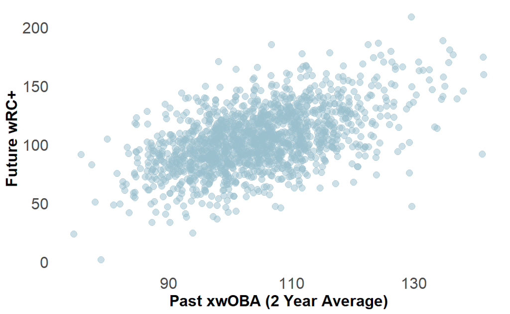

```r
ggplot(data = predict_batting_qualified, mapping = aes(x = est_woba_plus_2YrAvg, y = wRC_Plus_future)) +
  geom_point(size = 3, alpha = 0.5, color = "lightblue3") +
  xlab("Past xwOBA (2 Year Average)") + ylab("Future wRC+") +
  theme_minimal() +
  theme(legend.text = element_text(size = 16, face = "bold"), legend.title = element_blank(),
        axis.text.x = element_text(size = 16), axis.title.x = element_text(size = 16, face = "bold"),
        axis.text.y = element_text(size = 16), axis.title.y = element_text(size = 16, face = "bold"),
        panel.grid.major = element_blank(), panel.grid.minor = element_blank())
```

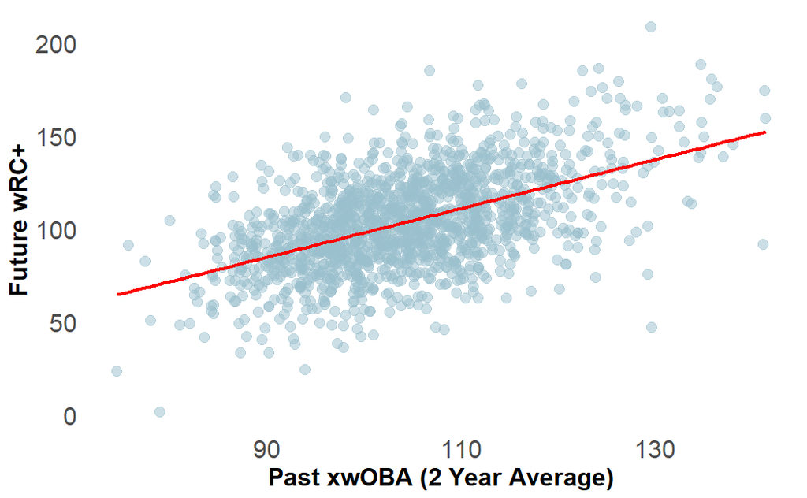

```r
ggplot(data = predict_batting_qualified, mapping = aes(x = est_woba_plus_2YrAvg, y = wRC_Plus_future)) +
  geom_point(size = 3, alpha = 0.5, color = "lightblue3") +
  geom_smooth(method = "lm", se = FALSE, color = "red") +
  xlab("Past xwOBA (2 Year Average)") + ylab("Future wRC+") +
  theme_minimal() +
  theme(legend.text = element_text(size = 16, face = "bold"), legend.title = element_blank(),
        axis.text.x = element_text(size = 16), axis.title.x = element_text(size = 16, face = "bold"),
        axis.text.y = element_text(size = 16), axis.title.y = element_text(size = 16, face = "bold"),
        panel.grid.major = element_blank(), panel.grid.minor = element_blank())
```

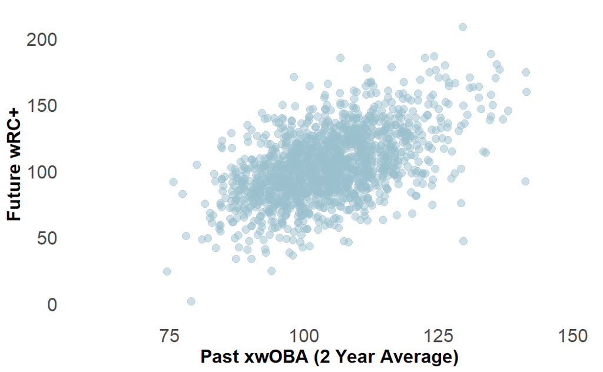

```r
extreme_points <- predict_batting_qualified %>%
  arrange(desc(est_woba_plus_2YrAvg)) %>%
  slice_head(n = 10) %>%
  bind_rows(
    predict_batting_qualified %>%
      arrange(est_woba_plus_2YrAvg) %>%
      slice_head(n = 10)
  ) %>%
  bind_rows(
    predict_batting_qualified %>%
      arrange(desc(wRC_Plus_future)) %>%
      slice_head(n = 10)
  ) %>%
  bind_rows(
    predict_batting_qualified %>%
      arrange(wRC_Plus_future) %>%
      slice_head(n = 10)
  ) %>%
  distinct()

ggplot(data = predict_batting_qualified, mapping = aes(x = est_woba_plus_2YrAvg, y = wRC_Plus_future)) +
  geom_point(size = 3, alpha = 0.5, color = "lightblue3") +
  xlab("Past xwOBA (2 Year Average)") + ylab("Future wRC+") +
  geom_text_repel(data = extreme_points, aes(label = paste0(Name, " (", Season_future, ")")),
                  nudge_x = 0.5, nudge_y = 1, size = 3, max.overlaps = 9) +
  expand_limits(x = c(min(predict_batting_qualified$est_woba_plus_past1) - 0.05, max(predict_batting_qualified$est_woba_plus_past1) + 0.05),
                y = c(min(predict_batting_qualified$wRC_Plus_future) - 5, max(predict_batting_qualified$wRC_Plus_future) + 5)) +
  theme_minimal() +
  theme(legend.text = element_text(size = 16, face = "bold"), legend.title = element_blank(),
        axis.text.x = element_text(size = 16), axis.title.x = element_text(size = 16, face = "bold"),
        axis.text.y = element_text(size = 16), axis.title.y = element_text(size = 16, face = "bold"),
        panel.grid.major = element_blank(), panel.grid.minor = element_blank(),
        plot.title = element_text(size = 16, face = "bold"))
```

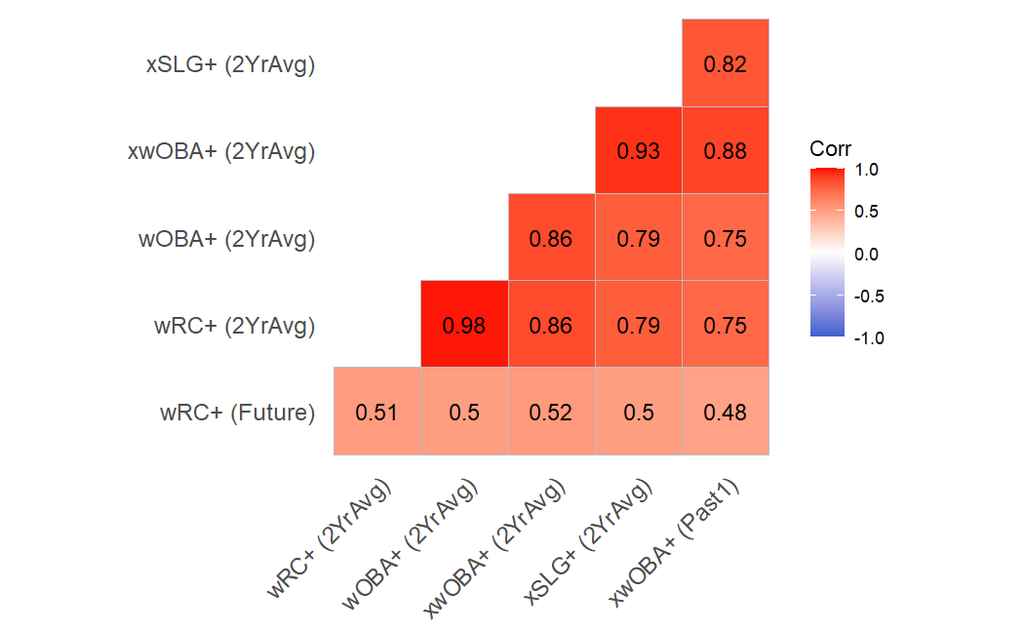

```r
vars <- predict_batting_qualified %>%
  select(est_woba_plus_2YrAvg, wRC_Plus_2YrAvg, wOBA_Plus_2YrAvg, est_slg_plus_2YrAvg, est_woba_plus_past1, wRC_Plus_future) %>%
  rename(`xwOBA+ (2YrAvg)` = est_woba_plus_2YrAvg, `wRC+ (2YrAvg)` = wRC_Plus_2YrAvg, `wOBA+ (2YrAvg)` = wOBA_Plus_2YrAvg, `xSLG+ (2YrAvg)` = est_slg_plus_2YrAvg, `xwOBA+ (Past1)` = est_woba_plus_past1, `wRC+ (Future)` = wRC_Plus_future)

cor_matrix <- cor(vars)

desired_order <- c("wRC+ (Future)", "wRC+ (2YrAvg)", "wOBA+ (2YrAvg)", "xwOBA+ (2YrAvg)", "xSLG+ (2YrAvg)", "xwOBA+ (Past1)")

cor_matrix_ordered <- cor_matrix[desired_order, desired_order]

ggcorrplot(cor_matrix_ordered, type = "lower", colors = c("royalblue3", "#FFFFFF", "red"), lab = TRUE) +
  theme(plot.title = element_text(face = "bold"),
        panel.grid.major = element_blank(),
        panel.grid.minor = element_blank())
```

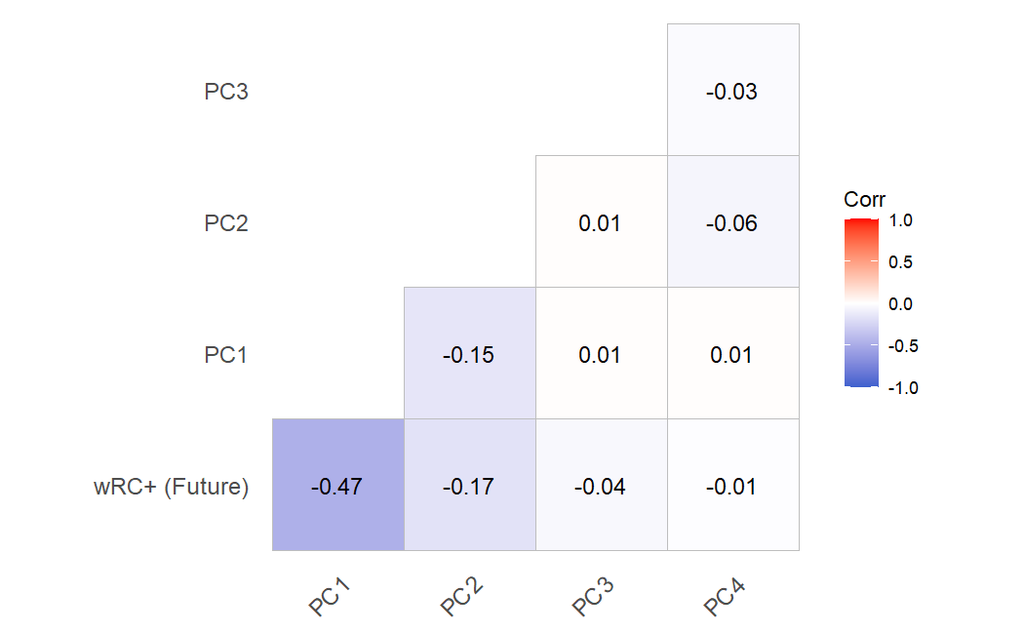

```r
vars <- predict_batting_qualified %>%
  select(PC1, PC2, PC3, PC4, wRC_Plus_future) %>%
  rename(`wRC+ (Future)` = wRC_Plus_future)

cor_matrix <- cor(vars)

desired_order <- c("wRC+ (Future)", "PC1", "PC2", "PC3", "PC4")

cor_matrix_ordered <- cor_matrix[desired_order, desired_order]

ggcorrplot(cor_matrix_ordered, type = "lower", colors = c("royalblue3", "#FFFFFF", "red"), lab = TRUE) +
  theme(plot.title = element_text(face = "bold"),
        panel.grid.major = element_blank(),
        panel.grid.minor = element_blank())
```

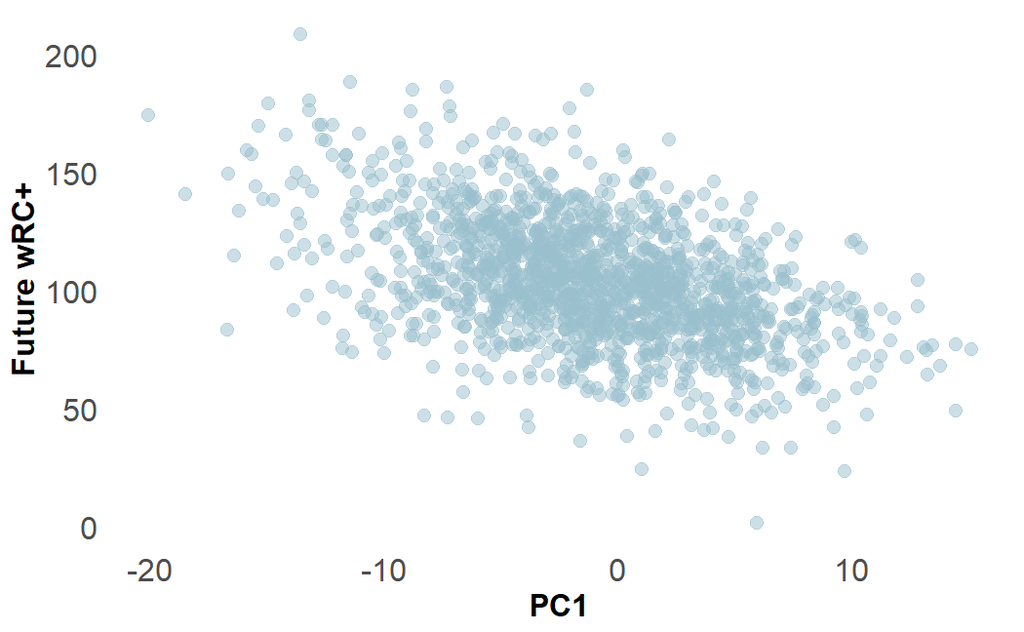

```r
ggplot(data = predict_batting_qualified, mapping = aes(x = PC1, y = wRC_Plus_future)) +
  geom_point(size = 3, alpha = 0.5, color = "lightblue3") +
  xlab("PC1") + ylab("Future wRC+") +
  theme_minimal() +
  theme(legend.text = element_text(size = 16, face = "bold"), legend.title = element_blank(),
        axis.text.x = element_text(size = 16), axis.title.x = element_text(size = 16, face = "bold"),
        axis.text.y = element_text(size = 16), axis.title.y = element_text(size = 16, face = "bold"),
        panel.grid.major = element_blank(), panel.grid.minor = element_blank())
```

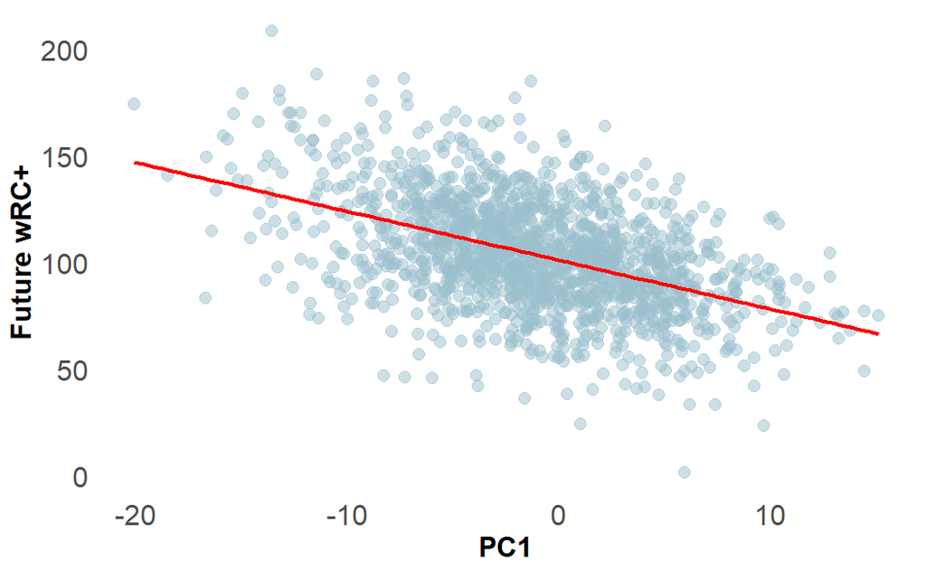

```r
ggplot(data = predict_batting_qualified, mapping = aes(x = PC1, y = wRC_Plus_future)) +
  geom_point(size = 3, alpha = 0.5, color = "lightblue3") +
  geom_smooth(method = "lm", se = FALSE, color = "red") +
  xlab("PC1") + ylab("Future wRC+") +
  theme_minimal() +
  theme(legend.text = element_text(size = 16, face = "bold"), legend.title = element_blank(),
        axis.text.x = element_text(size = 16), axis.title.x = element_text(size = 16, face = "bold"),
        axis.text.y = element_text(size = 16), axis.title.y = element_text(size = 16, face = "bold"),
        panel.grid.major = element_blank(), panel.grid.minor = element_blank())
```

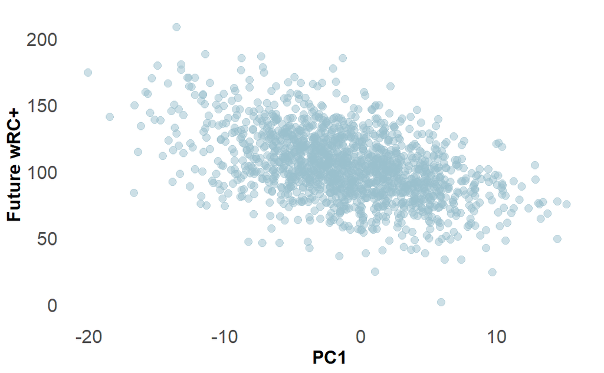

```r
extreme_points <- predict_batting_qualified %>%
  arrange(desc(PC1)) %>%
  slice_head(n = 10) %>%
  bind_rows(
    predict_batting_qualified %>%
      arrange(PC1) %>%
      slice_head(n = 10)
  ) %>%
  bind_rows(
    predict_batting_qualified %>%
      arrange(desc(wRC_Plus_future)) %>%
      slice_head(n = 10)
  ) %>%
  bind_rows(
    predict_batting_qualified %>%
      arrange(wRC_Plus_future) %>%
      slice_head(n = 10)
  ) %>%
  distinct()

ggplot(data = predict_batting_qualified, mapping = aes(x = PC1, y = wRC_Plus_future)) +
  geom_point(size = 3, alpha = 0.5, color = "lightblue3") +
  xlab("PC1") + ylab("Future wRC+") +
  geom_text_repel(data = extreme_points, aes(label = paste0(Name, " (", Season_future, ")")),
                  nudge_x = 0.5, nudge_y = 1, size = 3, max.overlaps = 9) +
  expand_limits(x = c(min(predict_batting_qualified$PC1) - 0.05, max(predict_batting_qualified$PC1) + 0.05),
                y = c(min(predict_batting_qualified$wRC_Plus_future) - 5, max(predict_batting_qualified$wRC_Plus_future) + 5)) +
  theme_minimal() +
  theme(legend.text = element_text(size = 16, face = "bold"), legend.title = element_blank(),
        axis.text.x = element_text(size = 16), axis.title.x = element_text(size = 16, face = "bold"),
        axis.text.y = element_text(size = 16), axis.title.y = element_text(size = 16, face = "bold"),
        panel.grid.major = element_blank(), panel.grid.minor = element_blank(),
        plot.title = element_text(size = 16, face = "bold"))
```

# Feature Selection

With a plethora of features to consider, including the new principal components, we will use machine learning to perform feature selection.

Before we do any model creation, we need to split the data into a training and testing set. The rule of thumb is to do an 80-20 or 75-25 split. It is incredibly important to hold out the test set because this serves as an unbiased estimate of how well our final trained model will generalize in production to new, previously unseen data.

For this model, we only consider seasons with at least 400 past PA and 200 PA because we don’t want to punish models for being drastically wrong when a player simply didn’t play enough to accumulate a descriptive, accurate wRC+. For example, if we projected a player to have a 100 wRC+ and he wound up with a 200 wRC+ in only 10 plate appearances, it is very likely that this player simply benefited from very limited playing time and that the model may not have been as wrong as any error metric would suggest.

We will perform an 80-20 train-test split and create 5 cross-validation folds for hyperparameter tuning. We opted to use cross-validation folds rather than a single validation set as we are working with a relatively small data frame. This way, every data point is involved in validation at some point and the aggregated average error metric across the 5 folds will provide a more reliable estimate of predictive accuracy than a single validation set would.

```r
# Split the dataset into a training set (60%), testing set (20%), and validation set (20%)
set.seed(40)
data_split <- initial_split(predict_batting_qualified, prop = 0.8)
train <- training(data_split)
test <- testing(data_split)
folds <- vfold_cv(train, v = 5)
```

Lastly, let’s tune and fit the model and save a variable importance plot to use for feature selection.

```r
# Create model specification
spec <- boost_tree(trees = tune(), min_n = tune(), tree_depth = tune(), learn_rate = tune(), sample_size = tune(), mtry = tune()) %>%
  set_mode("regression") %>%
  set_engine("xgboost")

num_predictors <- ncol(select(train, -ID, -PlayerId, -MLBAMID, -Name, -Season_future, -PA_future, -wRC_Plus_future))
mtry_param <- mtry(range = c(1, num_predictors))
params <- parameters(spec) %>% update(mtry = mtry_param)
# Create model recipe for preprocessing
rec <- recipe(wRC_Plus_future ~ ., data = train) %>%
  update_role(ID, PlayerId, MLBAMID, Name, Season_future, PA_future, new_role = "ID")

# Create workflow object
wf <- workflow() %>%
  add_model(spec) %>%
  add_recipe(rec)

# Hyperparameter tune and validate models using Bayesian optimization
tune_res <- wf %>%
  tune_bayes(resamples = folds,
             initial = 15,
             iter = 50,
             param_info = params,
             control = control_bayes(verbose = TRUE, no_improve = 10, seed = 40),
             metrics = metric_set(rmse))
```

[output not shown]

[output cut: 309 more lines]

[output not shown]

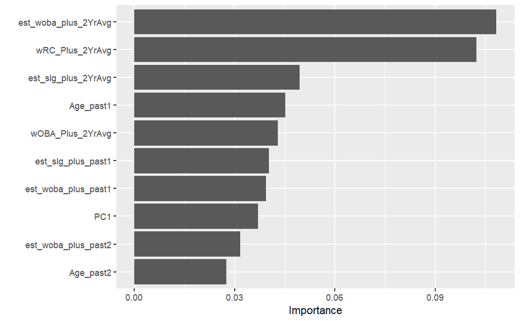

```r
# Select best hyperparameter setting
best_params <- select_best(tune_res, "rmse")

# Fit the final model
set.seed(40)
final_model <- wf %>%
  finalize_workflow(best_params) %>%
  fit(data = train)

# Generate feature importance plot
vip_plot <- final_model %>%
  extract_fit_parsnip() %>%
  vip()

vip_plot
```

The most important features were by far the past 2 year average xwOBA and past 2 year average wRC+, followed by 2 year average xSLG and the age of the player. We will proceed with the model building phase using both the full set of features and these 4 features alone, drastically reducing model complexity and computational run time, and potentially improving predictive power.

```r
# Select final set of features
train2 <- train %>%
  select(ID, PlayerId, MLBAMID, Name, Season_future, PA_future, est_woba_plus_2YrAvg, wRC_Plus_2YrAvg, est_slg_plus_2YrAvg, Age_past1, wRC_Plus_future)
test2 <- test %>%
  select(ID, PlayerId, MLBAMID, Name, Season_future, PA_future, est_woba_plus_2YrAvg, wRC_Plus_2YrAvg, est_slg_plus_2YrAvg, Age_past1, wRC_Plus_future)
folds <- vfold_cv(train, v = 5)

glimpse(train2)
```

```
Rows: 1,171
Columns: 11
$ ID                   <int> 310, 4315, 1457, 3331, 3360, 284, 3261, 3231, 3341, 4269, 2863, 2595, 4397, 170, 3917, 654, 41…
$ PlayerId             <int> 18577, 13510, 10264, 5930, 7304, 17988, 3708, 2434, 6368, 12856, 12552, 3174, 15429, 14551, 42…
$ MLBAMID              <int> 663647, 608070, 474832, 455976, 521692, 663886, 434658, 443558, 430945, 543807, 553993, 425783…
$ Name                 <chr> "Ke'Bryan Hayes", "José Ramírez", "Brandon Belt", "Nick Markakis", "Salvador Perez", "Tyler St…
$ Season_future        <int> 2023, 2017, 2021, 2018, 2018, 2023, 2018, 2018, 2018, 2017, 2019, 2019, 2017, 2023, 2017, 2022…
$ PA_future            <int> 525, 645, 381, 705, 544, 517, 216, 591, 613, 629, 662, 660, 665, 656, 576, 433, 650, 423, 686,…
$ est_woba_plus_2YrAvg <dbl> 96.51050, 101.10766, 113.45933, 103.83938, 100.17652, 102.42856, 87.74321, 126.68399, 101.9691…
$ wRC_Plus_2YrAvg      <dbl> 86.22314, 101.99240, 114.73725, 95.26007, 95.59648, 118.49175, 78.59141, 147.06483, 101.84289,…
$ est_slg_plus_2YrAvg  <dbl> 90.99946, 96.51262, 115.90498, 97.18504, 111.91809, 97.78230, 82.18256, 145.22618, 109.53115, …
$ Age_past1            <int> 25, 23, 32, 33, 27, 25, 36, 36, 31, 26, 26, 35, 24, 27, 31, 38, 29, 30, 23, 27, 28, 31, 26, 29…
$ wRC_Plus_future      <dbl> 101.06907, 146.35322, 158.60965, 113.71034, 88.40141, 84.55388, 51.46324, 132.82831, 98.08603,…
```

# Null and Naive Model

Before evaluating any advanced machine learning models, we need a performance baseline to determine if significant statistical learning has occurred. We will create this by making both a “null” and a “naive” model. The null model simulates what the error rate would be if we were to just randomly guess future wRC+ before the season starts. The null model achieves this by simply predicting league average wRC+ for every player. The naive model, simulating an educated guess, will use one feature, the 2 year mean of wRC+ for our purposes, and see how well that one feature alone predicts future data points.

```r
# Fit the null model, using the weighted average OBP in train as the prediction
null_pred <- 100

null_test_preds <- test %>%
  mutate(.pred = null_pred)

# Calculate testing error
null_testing_error <- rmse(data = null_test_preds, truth = "wRC_Plus_future", estimate = ".pred")

null_testing_error
```

| .metric | .estimator | .estimate |
| --- | --- | --- |
| rmse | standard | 26.15591 |

There we have it–the number to beat is an RMSE of 26.16. If we cannot craft a model that outperforms this, then no learning has occurred and it is certainly not worth using.

Next, we will fit a naive model with past 2 average wRC+. We anticipate this to outperform the null model enough to be useful. Additionally, we expect this simple model to perform similarly to some of the more complex models as our feature selection process revealed that this was the one of the most important features (wRC_Plus_2YrAvg).

```r
# Fit the naive model, using true talent OBP to predict next season OBP
naive_test_preds <- test %>%
  mutate(.pred = wRC_Plus_2YrAvg)

# Calculate testing error
naive_testing_error <- rmse(data = naive_test_preds, truth = "wRC_Plus_future", estimate = ".pred")

naive_testing_error
```

| .metric | .estimator | .estimate |
| --- | --- | --- |
| rmse | standard | 23.89285 |

As expected, the RMSE error metric improved, lowering from from 26.16 to 23.89. In other words, predicting next season wRC+ goes more smoothly when using wRC+ in past seasons than when randomly guessing or simply predicting league average. Let’s fit some more complicated models to see if we can outperform the naive model.

# Hyperparameter Tuning

More complicated models that require hyperparameter tuning will need a validation set to evaluate the quality of each hyperparameter combination. As mentioned previously, because we do not have a lot of data, we will use 5-fold cross-validation for the validation phase.

Now, let’s turn to Extreme Gradient Boosting using the xgboost package to try and outperform the naive model. Extreme Gradient Boosting is an extremely powerful supervised learning method for both regression and classification and often outperforms most other machine learning methods when working with tabular data. We will hyperparamter tune with both the full set of features and the set of selected features

```r
# Create model specification
spec_xgb <- boost_tree(trees = tune(), min_n = tune(), tree_depth = tune(), learn_rate = tune(), sample_size = tune(), mtry = tune()) %>%
  set_mode("regression") %>%
  set_engine("xgboost")

num_predictors <- ncol(select(train, -ID, -PlayerId, -MLBAMID, -Name, -Season_future, -PA_future, -wRC_Plus_future))
mtry_param <- mtry(range = c(1, num_predictors))
params <- parameters(spec_xgb) %>% update(mtry = mtry_param)

# Create model recipe for preprocessing
rec <- recipe(wRC_Plus_future ~ ., data = train) %>%
  update_role(ID, PlayerId, MLBAMID, Name, Season_future, PA_future, new_role = "ID")

# Create workflow object
wf_xgb <- workflow() %>%
  add_model(spec_xgb) %>%
  add_recipe(rec)

# Hyperparameter tune and validate models using Bayesian optimization
tune_res_xgb <- wf_xgb %>%
  tune_bayes(resamples = folds,
             initial = 15,
             iter = 50,
             param_info = params,
             control = control_bayes(verbose = TRUE, no_improve = 10, seed = 40),
             metrics = metric_set(rmse))
```

[output not shown]

[output cut: 309 more lines]

[output not shown]

```r
# Collect validation errors
xgb_val_error <- tune_res_xgb %>%
  collect_metrics() %>%
  filter(.metric == "rmse")

# Select best hyperparameter setting
best_params_xgb <- select_best(tune_res_xgb, "rmse")
```

```r
xgb_val_error %>% arrange(mean)
```

| mtry | trees | min_n | tree_depth | learn_rate | sample_size | .metric | .estimator | mean | n | std_err | .config | .iter |
| --- | --- | --- | --- | --- | --- | --- | --- | --- | --- | --- | --- | --- |
| 8 | 1326 | 31 | 2 | 0.014452807 | 0.6085730 | rmse | standard | 21.72329 | 5 | 0.3700343 | Preprocessor1_Model01 | 0 |
| 18 | 1722 | 17 | 14 | 0.004661904 | 0.2798570 | rmse | standard | 21.72369 | 5 | 0.3475117 | Preprocessor1_Model03 | 0 |
| 50 | 685 | 39 | 3 | 0.013210023 | 0.9886813 | rmse | standard | 21.75661 | 5 | 0.3805177 | Iter8 | 8 |
| 10 | 828 | 29 | 11 | 0.008230711 | 0.1478915 | rmse | standard | 21.79971 | 5 | 0.2091935 | Preprocessor1_Model02 | 0 |
| 50 | 1989 | 23 | 8 | 0.004203388 | 0.1862438 | rmse | standard | 21.81885 | 5 | 0.2971872 | Preprocessor1_Model07 | 0 |
| 14 | 1169 | 10 | 9 | 0.004184103 | 0.7795093 | rmse | standard | 21.83294 | 5 | 0.3749580 | Iter4 | 4 |
| 56 | 1439 | 31 | 5 | 0.002728315 | 0.2149797 | rmse | standard | 21.85733 | 5 | 0.2516828 | Iter1 | 1 |
| 47 | 614 | 18 | 3 | 0.023880798 | 0.9712750 | rmse | standard | 21.96795 | 5 | 0.3859032 | Iter3 | 3 |
| 91 | 339 | 15 | 11 | 0.023191176 | 0.5662460 | rmse | standard | 22.07120 | 5 | 0.3738023 | Preprocessor1_Model13 | 0 |
| 13 | 18 | 10 | 3 | 0.280683490 | 0.8898761 | rmse | standard | 22.11756 | 5 | 0.3967383 | Iter7 | 7 |

[output cut: 15 more lines]

```r
# Create model specification
spec_xgb_select <- boost_tree(trees = tune(), min_n = tune(), tree_depth = tune(), learn_rate = tune(), sample_size = tune(), mtry = tune()) %>%
  set_mode("regression") %>%
  set_engine("xgboost")

num_predictors <- ncol(select(train2, -ID, -PlayerId, -MLBAMID, -Name, -Season_future, -PA_future, -wRC_Plus_future))
mtry_param <- mtry(range = c(1, num_predictors))
params <- parameters(spec_xgb_select) %>% update(mtry = mtry_param)

# Create model recipe for preprocessing
rec_select <- recipe(wRC_Plus_future ~ ., data = train2) %>%
  update_role(ID, PlayerId, MLBAMID, Name, Season_future, PA_future, new_role = "ID")

# Create workflow object
wf_xgb_select <- workflow() %>%
  add_model(spec_xgb_select) %>%
  add_recipe(rec_select)

# Hyperparameter tune and validate models using Bayesian optimization
tune_res_xgb_select <- wf_xgb_select %>%
  tune_bayes(resamples = folds,
             initial = 15,
             iter = 50,
             param_info = params,
             control = control_bayes(verbose = TRUE, no_improve = 10, seed = 40),
             metrics = metric_set(rmse))
```

[output not shown]

[output cut: 453 more lines]

[output not shown]

```r
# Collect validation errors
xgb_select_val_error <- tune_res_xgb_select %>%
  collect_metrics() %>%
  filter(.metric == "rmse")

# Select best hyperparameter setting
best_params_xgb_select <- select_best(tune_res_xgb_select, "rmse")
```

```r
xgb_select_val_error %>% arrange(mean)
```

| mtry | trees | min_n | tree_depth | learn_rate | sample_size | .metric | .estimator | mean | n | std_err | .config | .iter |
| --- | --- | --- | --- | --- | --- | --- | --- | --- | --- | --- | --- | --- |
| 2 | 1231 | 6 | 3 | 0.005886015 | 0.1004520 | rmse | standard | 21.54373 | 5 | 0.3023762 | Iter4 | 4 |
| 1 | 931 | 16 | 14 | 0.037298270 | 0.1085562 | rmse | standard | 21.78970 | 5 | 0.2288104 | Iter1 | 1 |
| 2 | 218 | 26 | 8 | 0.017095838 | 0.2060355 | rmse | standard | 21.79367 | 5 | 0.3187565 | Iter11 | 11 |
| 2 | 1879 | 20 | 9 | 0.021222254 | 0.1226451 | rmse | standard | 21.79490 | 5 | 0.2276562 | Preprocessor1_Model05 | 0 |
| 1 | 1342 | 3 | 2 | 0.018197205 | 0.2196810 | rmse | standard | 21.80193 | 5 | 0.2987947 | Iter9 | 9 |
| 1 | 198 | 8 | 4 | 0.024934821 | 0.9798555 | rmse | standard | 21.81103 | 5 | 0.3498961 | Iter12 | 12 |
| 2 | 1888 | 3 | 2 | 0.014292013 | 0.2873843 | rmse | standard | 21.90399 | 5 | 0.2988668 | Iter6 | 6 |
| 2 | 908 | 33 | 7 | 0.013862407 | 0.9365929 | rmse | standard | 22.08402 | 5 | 0.3865851 | Preprocessor1_Model07 | 0 |
| 2 | 831 | 39 | 4 | 0.008508197 | 0.1136640 | rmse | standard | 22.24742 | 5 | 0.2221004 | Iter7 | 7 |
| 1 | 573 | 37 | 3 | 0.017007223 | 0.1052670 | rmse | standard | 22.25686 | 5 | 0.2273230 | Iter5 | 5 |

[output cut: 19 more lines]

```r
# Fit the final model
set.seed(40)
final_model <- wf_xgb %>%
  finalize_workflow(best_params_xgb) %>%
  fit(data = train)

# Generate predictions on test set
test_preds <- predict(final_model, test) %>%
  bind_cols(test) %>%
  select(ID, PlayerId, Name, PA_future, wRC_Plus_future, .pred)

# Calculate and save testing error
final_testing_error <- rmse(data = test_preds, truth = "wRC_Plus_future", estimate = ".pred")

final_testing_error
```

| .metric | .estimator | .estimate |
| --- | --- | --- |
| rmse | standard | 21.60398 |

```r
# Save final model so it can be applied to new data
saveRDS(final_model, "final_model.rds")
```

# Conclusion

By training a model that performed better than the null and naive models on the test set, we successfully found an adequate function between past offensive performance and future offensive performance. We can now use this model to project player results before the season even starts.

# Generate 2024 Predictions

```r
# Restructure data to feed into model
predict_2024 <- batting_2023 %>%
  filter(PA >= 300) %>%
  mutate(Season_future = Season + 1, wRC_Plus_future = NA, PA_future = NA) %>%
  select(PlayerId, MLBAMID, Name, Season_future, wRC_Plus_future, PA_future) %>%
  left_join(batting_2023 %>% rename_with(~paste0(., "_past1"), -(1:3)), by = c("PlayerId", "MLBAMID", "Name")) %>%
  left_join(batting_2023 %>% rename_with(~paste0(., "_past2"), -(1:3)), by = c("PlayerId", "MLBAMID", "Name"))
```

```r
predict_2024 <- predict_2024 %>%
  mutate(AVG_Plus_2YrAvg = get_2year_mean(AVG_Plus_past1, PA_past1, AVG_Plus_past2, PA_past2),
         OBP_Plus_2YrAvg = get_2year_mean(OBP_Plus_past1, PA_past1, OBP_Plus_past2, PA_past2),
         SLG_Plus_2YrAvg = get_2year_mean(SLG_Plus_past1, PA_past1, SLG_Plus_past2, PA_past2),
         BB_Rate_Plus_2YrAvg = get_2year_mean(BB_Rate_Plus_past1, PA_past1, BB_Rate_Plus_past2, PA_past2),
         K_Rate_Plus_2YrAvg = get_2year_mean(K_Rate_Plus_past1, PA_past1, K_Rate_Plus_past2, PA_past2),
         wRC_Plus_2YrAvg = get_2year_mean(wRC_Plus_past1, PA_past1, wRC_Plus_past2, PA_past2),
         O_Swing_Rate_2YrAvg = get_2year_mean(O_Swing_Rate_past1, PA_past1, O_Swing_Rate_past2, PA_past2),
         Z_Swing_Rate_2YrAvg = get_2year_mean(Z_Swing_Rate_past1, PA_past1, Z_Swing_Rate_past2, PA_past2),
         Swing_Rate_2YrAvg = get_2year_mean(Swing_Rate_past1, PA_past1, Swing_Rate_past2, PA_past2),
         O_Contact_Rate_2YrAvg = get_2year_mean(O_Contact_Rate_past1, PA_past1, O_Contact_Rate_past2, PA_past2),
         Z_Contact_Rate_2YrAvg = get_2year_mean(Z_Contact_Rate_past1, PA_past1, Z_Contact_Rate_past2, PA_past2),
         Contact_Rate_2YrAvg = get_2year_mean(Contact_Rate_past1, PA_past1, Contact_Rate_past2, PA_past2),
         Pull_Rate_Plus_2YrAvg = get_2year_mean(Pull_Rate_Plus_past1, PA_past1, Pull_Rate_Plus_past2, PA_past2),
         Cent_Rate_Plus_2YrAvg = get_2year_mean(Cent_Rate_Plus_past1, PA_past1, Cent_Rate_Plus_past2, PA_past2),
         Oppo_Rate_Plus_2YrAvg = get_2year_mean(Oppo_Rate_Plus_past1, PA_past1, Oppo_Rate_Plus_past2, PA_past2),
         GB_Rate_Plus_2YrAvg = get_2year_mean(GB_Rate_Plus_past1, PA_past1, GB_Rate_Plus_past2, PA_past2),
         avg_hit_angle_2YrAvg = get_2year_mean(avg_hit_angle_past1, PA_past1, avg_hit_angle_past2, PA_past2),
         anglesweetspotpercent_2YrAvg = get_2year_mean(anglesweetspotpercent_past1, PA_past1, anglesweetspotpercent_past2, PA_past2),
         max_hit_speed_2YrAvg = get_2year_mean(max_hit_speed_past1, PA_past1, max_hit_speed_past2, PA_past2),
         avg_hit_speed_2YrAvg = get_2year_mean(avg_hit_speed_past1, PA_past1, avg_hit_speed_past2, PA_past2),
         ev50_2YrAvg = get_2year_mean(ev50_past1, PA_past1, ev50_past2, PA_past2),
         fbld_2YrAvg = get_2year_mean(fbld_past1, PA_past1, fbld_past2, PA_past2),
         gb_2YrAvg = get_2year_mean(gb_past1, PA_past1, gb_past2, PA_past2),
         max_distance_2YrAvg = get_2year_mean(max_distance_past1, PA_past1, max_distance_past2, PA_past2),
         avg_distance_2YrAvg = get_2year_mean(avg_distance_past1, PA_past1, avg_distance_past2, PA_past2),
         avg_hr_distance_2YrAvg = get_2year_mean(avg_hr_distance_past1, PA_past1, avg_hr_distance_past2, PA_past2),
         ev95percent_2YrAvg = get_2year_mean(ev95percent_past1, PA_past1, ev95percent_past2, PA_past2),
         brl_percent_2YrAvg = get_2year_mean(brl_percent_past1, PA_past1, brl_percent_past2, PA_past2),
         brl_pa_2YrAvg = get_2year_mean(brl_pa_past1, PA_past1, brl_pa_past2, PA_past2),
         est_ba_plus_2YrAvg = get_2year_mean(est_ba_plus_past1, PA_past1, est_ba_plus_past2, PA_past2),
         est_slg_plus_2YrAvg = get_2year_mean(est_slg_plus_past1, PA_past1, est_slg_plus_past2, PA_past2),
         est_woba_plus_2YrAvg = get_2year_mean(est_woba_plus_past1, PA_past1, est_woba_plus_past2, PA_past2),
         wOBA_Plus_2YrAvg = get_2year_mean(wOBA_Plus_past1, PA_past1, wOBA_Plus_past2, PA_past2),
         Z_O_Swing_Rate_2YrAvg = get_2year_mean(Z_O_Swing_Rate_past1, PA_past1, Z_O_Swing_Rate_past2, PA_past2),
         PA_past1 = ifelse(is.na(PA_past1), 0, PA_past1), PA_past2 = ifelse(is.na(PA_past2), 0, PA_past2),
         PA_past_total = PA_past1 + PA_past2)

predict_2024 <- predict_2024 %>% mutate(ID = row_number()) %>% select(ID, everything())

# Calculate PC1

# Standardize the data
df <- predict_2024 %>%
  select(-PlayerId, -MLBAMID, -Name, -Season_future, -wRC_Plus_future, -PA_future)

# Separate ID and features
id_column <- df$ID
features <- df %>% select(-ID)  # Exclude ID column for PCA

# Standardize the features
features_standardized <- scale(features[, sapply(features, is.numeric)])

# Apply PCA
pca_features <- predict(pca_result, features_standardized)

df_pca <- as.data.frame(pca_features[, 1:4])

# Add the ID column back to the PCA features dataframe
df_pca$ID <- id_column

# Merge PCA features with the original dataframe
predict_2024 <- merge(predict_2024, df_pca, by = "ID")

# Select final features
#predict_2024 <- predict_2024 %>%
  #select(ID, PlayerId, MLBAMID, Name, Season_future, PA_future, PC1, xwOBA_2YrAvg, wRC_Plus_2YrAvg, wRC_Plus_future)

glimpse(predict_2024)
```

```
Rows: 293
Columns: 120
$ ID                           <int> 1, 2, 3, 4, 5, 6, 7, 8, 9, 10, 11, 12, 13, 14, 15, 16, 17, 18, 19, 20, 21, 22, 23, 24,…
$ PlayerId                     <int> 1744, 2136, 2396, 2967, 3473, 4892, 4940, 4949, 5235, 5254, 5297, 5343, 5361, 5417, 58…
$ MLBAMID                      <int> 408234, 444482, 467793, 502054, 519203, 519058, 518792, 519317, 457759, 543257, 543305…
$ Name                         <chr> "Miguel Cabrera", "David Peralta", "Carlos Santana", "Tommy Pham", "Anthony Rizzo", "M…
$ Season_future                <dbl> 2024, 2024, 2024, 2024, 2024, 2024, 2024, 2024, 2024, 2024, 2024, 2024, 2024, 2024, 20…
$ wRC_Plus_future              <lgl> NA, NA, NA, NA, NA, NA, NA, NA, NA, NA, NA, NA, NA, NA, NA, NA, NA, NA, NA, NA, NA, NA…
$ PA_future                    <lgl> NA, NA, NA, NA, NA, NA, NA, NA, NA, NA, NA, NA, NA, NA, NA, NA, NA, NA, NA, NA, NA, NA…
$ Season_past1                 <int> 2023, 2023, 2023, 2023, 2023, 2023, 2023, 2023, 2023, 2023, 2023, 2023, 2023, 2023, 20…
$ Age_past1                    <int> 40, 35, 37, 35, 33, 34, 33, 33, 38, 33, 33, 36, 33, 33, 31, 33, 34, 35, 36, 33, 34, 36…
$ PA_past1                     <int> 370, 422, 619, 481, 421, 386, 377, 415, 626, 420, 312, 320, 730, 410, 454, 326, 309, 4…
$ AVG_Plus_past1               <dbl> 104.34634, 103.54087, 95.98848, 102.33513, 98.86847, 99.69496, 107.77149, 77.55498, 11…
$ OBP_Plus_past1               <dbl> 101.45825, 90.89355, 98.44630, 101.60986, 103.40442, 91.57143, 105.04030, 86.65605, 10…
$ SLG_Plus_past1               <dbl> 85.78644, 91.40317, 103.01857, 107.08046, 91.78958, 94.80788, 113.57346, 102.10189, 11…
```

[output cut: 107 more lines]

```r
preds_2024 <- predict(final_model, predict_2024) %>%
  bind_cols(predict_2024) %>%
  select(ID, PlayerId, Name, PA_future, wRC_Plus_future, .pred)
```

```r
preds_2024 <- preds_2024 %>%
  select(Name, .pred) %>%
  rename(wRC_Plus_predicted = .pred) %>%
  mutate(wRC_Plus_predicted = round(wRC_Plus_predicted, 0)) %>%
  arrange(desc(wRC_Plus_predicted)) %>%
  rename(`Predicted wRC+` = wRC_Plus_predicted)

preds_2024
```

| Name | Predicted wRC+ |
| --- | --- |
| Ronald Acuña Jr. | 161 |
| Yordan Alvarez | 155 |
| Matt Olson | 149 |
| Shohei Ohtani | 148 |
| Juan Soto | 145 |
| Corey Seager | 144 |
| Kyle Tucker | 141 |
| Aaron Judge | 140 |
| Vladimir Guerrero Jr. | 137 |
| Yandy Díaz | 135 |

[output cut: 283 more lines]

# Limitations and Future Work

1. Only handle players with certain amount of playing time
2. Way to predict rookies by incorporating minor league info